# Amandafw_FinalHomeworkCode_03

[figure not shown]

## Uploading data into R

```r
library(curl)
f <- curl("https://raw.githubusercontent.com/fuzzyatelin/fuzzyatelin.github.io/master/AN588_Fall23/zombies.csv")
d <- read.csv(f, header = TRUE, sep = ",", stringsAsFactors = FALSE) #this is the typical path used in challenges but would give an error for me - "Error in open.connection(file, "rt")" or another error with the final code line
#or
d <- read.csv("zombies.csv", header = TRUE, sep = ",", stringsAsFactors = FALSE) #this seemed to be more effective
head(d)
```

```
##   id first_name last_name gender   height   weight zombies_killed
## 1  1      Sarah    Little Female 62.88951 132.0872              2
## 2  2       Mark    Duncan   Male 67.80277 146.3753              5
## 3  3    Brandon     Perez   Male 72.12908 152.9370              1
## 4  4      Roger   Coleman   Male 66.78484 129.7418              5
## 5  5      Tammy    Powell Female 64.71832 132.4265              4
## 6  6    Anthony     Green   Male 71.24326 152.5246              1
##   years_of_education                           major      age
## 1                  1                medicine/nursing 17.64275
## 2                  3 criminal justice administration 22.58951
## 3                  1                       education 21.91276
## 4                  6                  energy studies 18.19058
## 5                  3                       logistics 21.10399
## 6                  4                  energy studies 21.48355
```

```r
summary(d)
```

```
##        id          first_name         last_name            gender
##  Min.   :   1.0   Length:1000        Length:1000        Length:1000
##  1st Qu.: 250.8   Class :character   Class :character   Class :character
##  Median : 500.5   Mode  :character   Mode  :character   Mode  :character
##  Mean   : 500.5
##  3rd Qu.: 750.2
##  Max.   :1000.0
##      height          weight       zombies_killed   years_of_education
##  Min.   :54.15   Min.   : 90.29   Min.   : 0.000   Min.   :0.000
##  1st Qu.:64.68   1st Qu.:131.81   1st Qu.: 2.000   1st Qu.:2.000
##  Median :67.50   Median :142.89   Median : 3.000   Median :3.000
##  Mean   :67.63   Mean   :143.91   Mean   : 2.992   Mean   :2.996
##  3rd Qu.:70.38   3rd Qu.:156.28   3rd Qu.: 4.000   3rd Qu.:4.000
##  Max.   :80.53   Max.   :210.79   Max.   :11.000   Max.   :8.000
##     major                age
##  Length:1000        Min.   :10.66
##  Class :character   1st Qu.:18.07
##  Mode  :character   Median :19.90
##                     Mean   :20.05
##                     3rd Qu.:21.94
##                     Max.   :29.59
```

```
+ you made a good point about the more effective line of code to read the csv file. it's the same code i used.  - Sofia
```

## Question 1

```r
#Calculate the population mean and standard deviation for each quantitative random variable (height, weight, age, number of zombies killed, and years of education). NOTE: You will not want to use the built in var() and sd() commands as these are for samples.
names(d)
```

```
##  [1] "id"                 "first_name"         "last_name"
##  [4] "gender"             "height"             "weight"
##  [7] "zombies_killed"     "years_of_education" "major"
## [10] "age"
```

```r
mean(d$height, na.rm = TRUE) #the mean for heights
```

```
## [1] 67.6301
```

```r
h <- d$height
sqrt(sum((h - mean(h))^2)/length(h)) #pop standard deviation is the square root of the pop variance; population variance is the sum of squares divided by # of values
```

```
## [1] 4.30797
```

```r
mean(d$weight, na.rm = TRUE)
```

```
## [1] 143.9075
```

```r
w <- d$weight
sqrt(sum((w - mean(w))^2)/length(w)) #pop sd
```

```
## [1] 18.39186
```

```r
mean(d$age, na.rm = TRUE)
```

```
## [1] 20.04696
```

```r
a <- d$age
sqrt(sum((a - mean(a))^2)/length(a)) #pop sd
```

```
## [1] 2.963583
```

```r
mean(d$zombies_killed, na.rm = TRUE)
```

```
## [1] 2.992
```

```r
z <- d$zombies_killed
sqrt(sum((z - mean(z))^2)/length(z)) #pop sd
```

```
## [1] 1.747551
```

```r
mean(d$years_of_education, na.rm = TRUE)
```

```
## [1] 2.996
```

```r
y <- d$years_of_education
sqrt(sum((y - mean(y))^2)/length(y)) #pop sd
```

```
## [1] 1.675704
```

[output not shown]

## Question 2

```r
#Use {ggplot} to make boxplots of each of these variables by gender.
library(ggplot2)
names(d)
```

```
##  [1] "id"                 "first_name"         "last_name"
##  [4] "gender"             "height"             "weight"
##  [7] "zombies_killed"     "years_of_education" "major"
## [10] "age"
```

```r
h <- ggplot(data = d, aes(x = gender, y = height)) #ggplot requires entering the dataset and aes for the x and y plots
h <- h + geom_boxplot() #this makes it a box plot
h <- h + ylab("Height") + xlab("Gender") #renames the x and y axis titles

w <- ggplot(data = d, aes(x = gender, y = weight))
w <- w + geom_boxplot()
w <- w + ylab("Weight") + xlab("Gender")

a <- ggplot(data = d, aes(x = gender, y = age))
a <- a + geom_boxplot()
a <- a + ylab("Age") + xlab("Gender")

z <- ggplot(data = d, aes(x = gender, y = zombies_killed))
z <- z + geom_boxplot()
z <- z + ylab("Zombies Killed") + xlab("Gender")

y <- ggplot(data = d, aes(x = gender, y = years_of_education))
y <- y + geom_boxplot()
y <- y + ylab("Years of Education") + xlab("Gender")
```

## Question 3

```r
#Use {ggplot} to make scatterplots of height and weight in relation to age. Do these variables seem to be related? In what way?
p <- ggplot(data = d, aes(x = height, y = age)) #entering the data
p <- p + xlab("Height") + ylab("Age")  #renaming the axis
p <- p + geom_point()  #make a scatterplot
p <- p + geom_smooth(method = "lm", fullrange = TRUE) #adding regression lines

w <- ggplot(data = d, aes(x = weight, y = age)) #entering the data
w <- w + xlab("Weight") + ylab("Age")  #renaming the axis
w <- w + geom_point()  #make a scatterplot
w <- w + geom_smooth(method = "lm", fullrange = TRUE)
```

## Question 4

```r
#Using histograms and Q-Q plots, check whether the quantitative variables seem to be drawn from a normal distribution. Which seem to be and which do not (hint: not all are drawn from the normal distribution)? For those that are not normal, can you determine from which common distribution they are drawn?
summary(d)
```

```
##        id          first_name         last_name            gender
##  Min.   :   1.0   Length:1000        Length:1000        Length:1000
##  1st Qu.: 250.8   Class :character   Class :character   Class :character
##  Median : 500.5   Mode  :character   Mode  :character   Mode  :character
##  Mean   : 500.5
##  3rd Qu.: 750.2
##  Max.   :1000.0
##      height          weight       zombies_killed   years_of_education
##  Min.   :54.15   Min.   : 90.29   Min.   : 0.000   Min.   :0.000
##  1st Qu.:64.68   1st Qu.:131.81   1st Qu.: 2.000   1st Qu.:2.000
##  Median :67.50   Median :142.89   Median : 3.000   Median :3.000
##  Mean   :67.63   Mean   :143.91   Mean   : 2.992   Mean   :2.996
##  3rd Qu.:70.38   3rd Qu.:156.28   3rd Qu.: 4.000   3rd Qu.:4.000
##  Max.   :80.53   Max.   :210.79   Max.   :11.000   Max.   :8.000
##     major                age
##  Length:1000        Min.   :10.66
##  Class :character   1st Qu.:18.07
##  Mode  :character   Median :19.90
##                     Mean   :20.05
##                     3rd Qu.:21.94
##                     Max.   :29.59
```

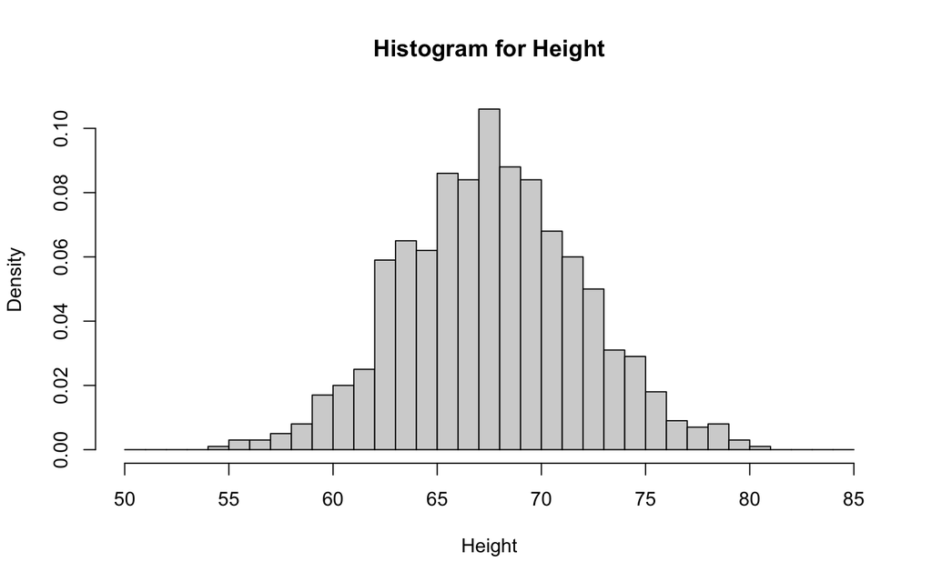

```r
#creating histogram & Q-Q plots with height:
hist(d$height, breaks = seq(from = 50, to = 85, by = 1), probability = TRUE, xlab = "Height", main = "Histogram for Height") #the breaks were determined with summary(d) from the min and the max values
```

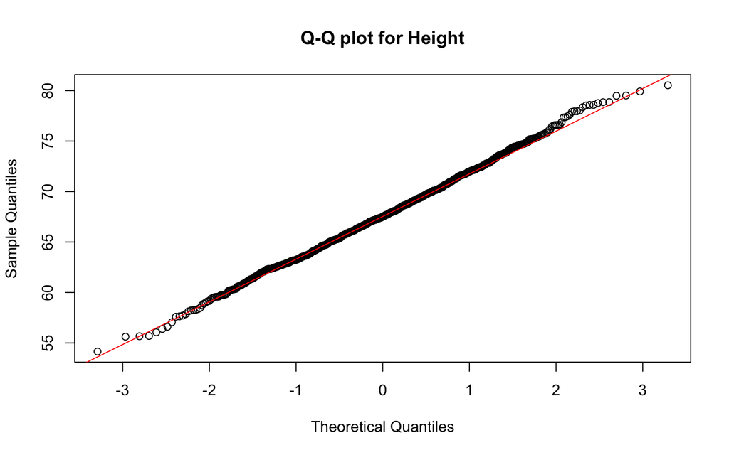

```r
qqnorm(d$height, main = "Q-Q plot for Height")
qqline(d$height, col = "red")
```

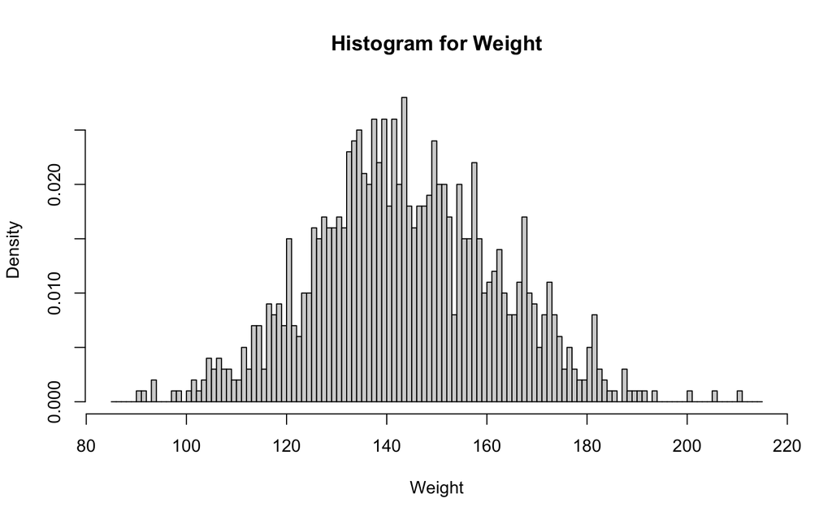

```r
#histogram for weight
hist(d$weight, breaks = seq(from = 85, to = 215, by = 1), probability = TRUE, xlab = "Weight", main = "Histogram for Weight")
```

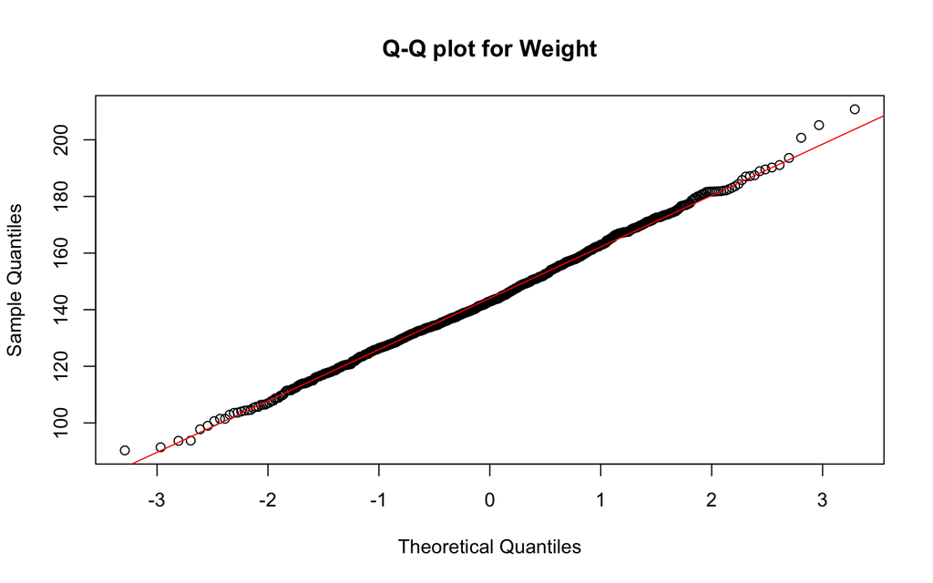

```r
qqnorm(d$weight, main = "Q-Q plot for Weight")
qqline(d$weight, col = "red")
```

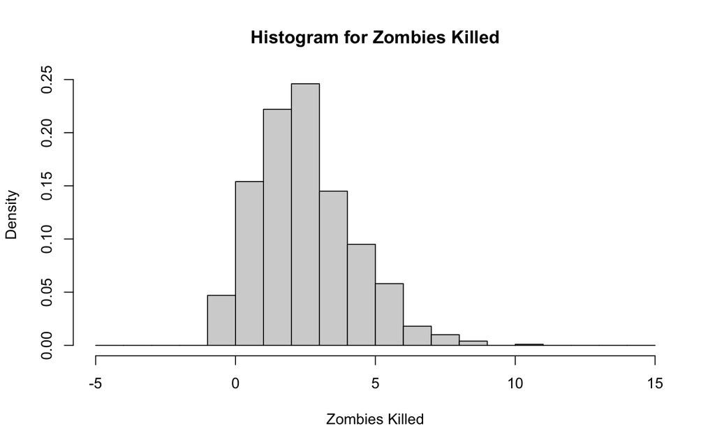

```r
#histogram for zombies killed
hist(d$zombies_killed, breaks = seq(from = -5, to = 15, by = 1), probability = TRUE, xlab = "Zombies Killed", main = "Histogram for Zombies Killed")
```

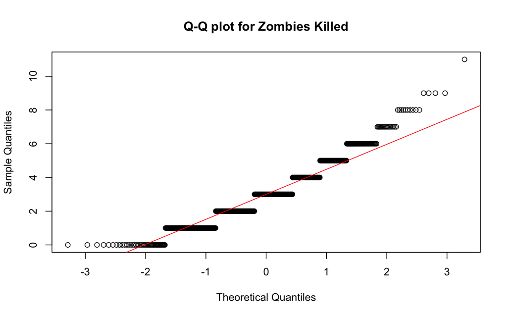

```r
qqnorm(d$zombies_killed, main = "Q-Q plot for Zombies Killed")
qqline(d$zombies_killed, col = "red")
```

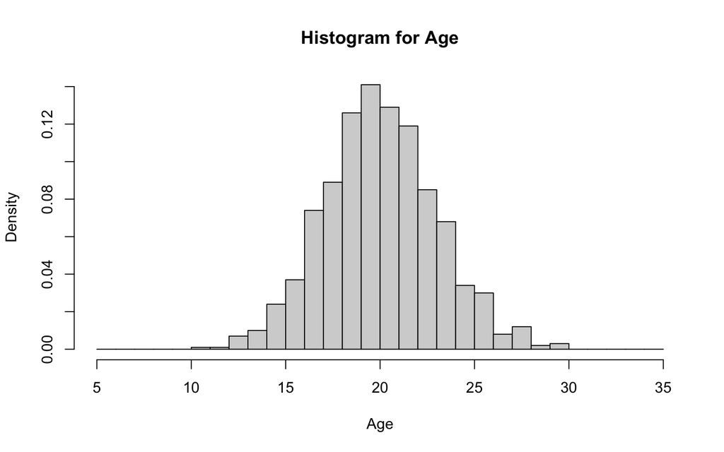

```r
#histogram for age
hist(d$age, breaks = seq(from = 5, to = 35, by = 1), probability = TRUE, xlab = "Age", main = "Histogram for Age")
```

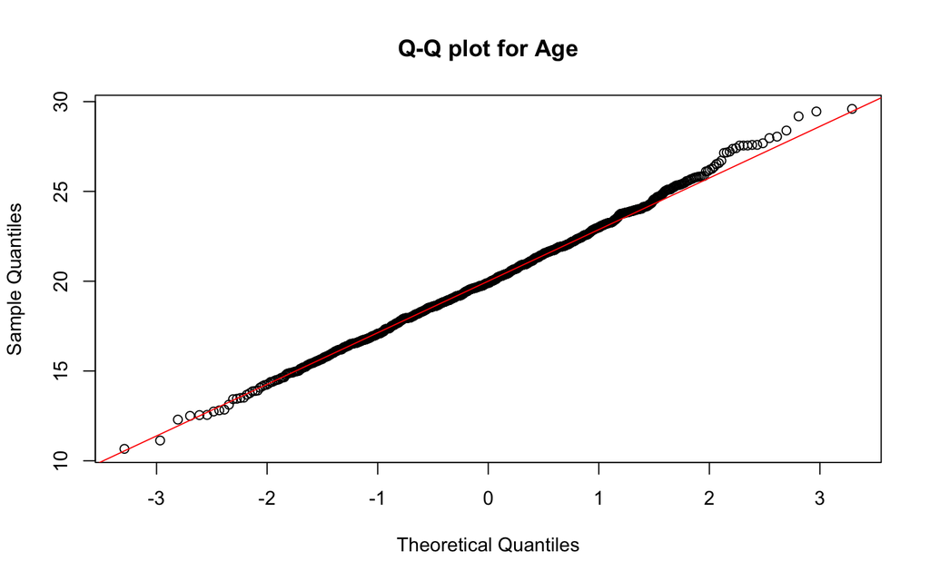

```r
qqnorm(d$age, main = "Q-Q plot for Age")
qqline(d$age, col = "red")
```

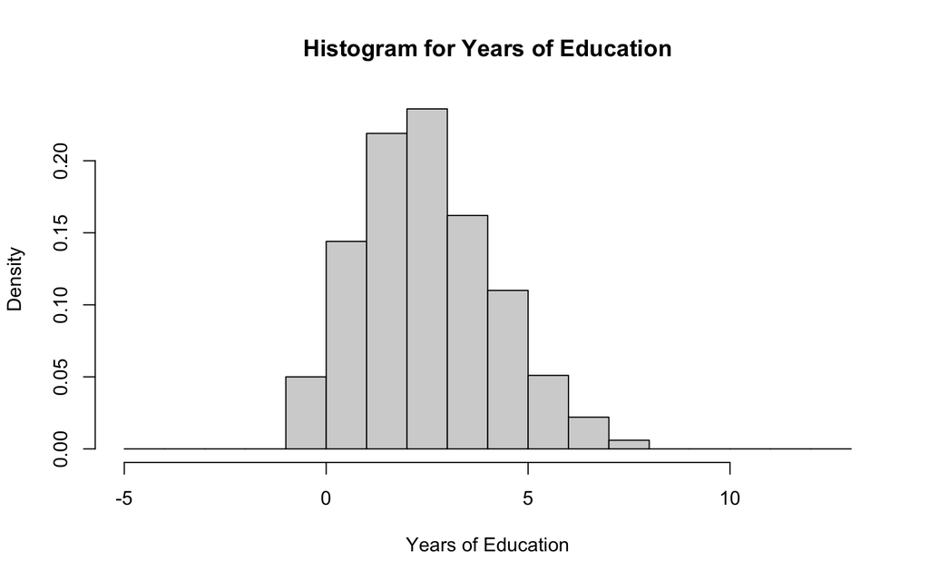

```r
#histogram for years of education
hist(d$years_of_education, breaks = seq(from = -5, to = 13, by = 1), probability = TRUE, xlab = "Years of Education", main = "Histogram for Years of Education")
```

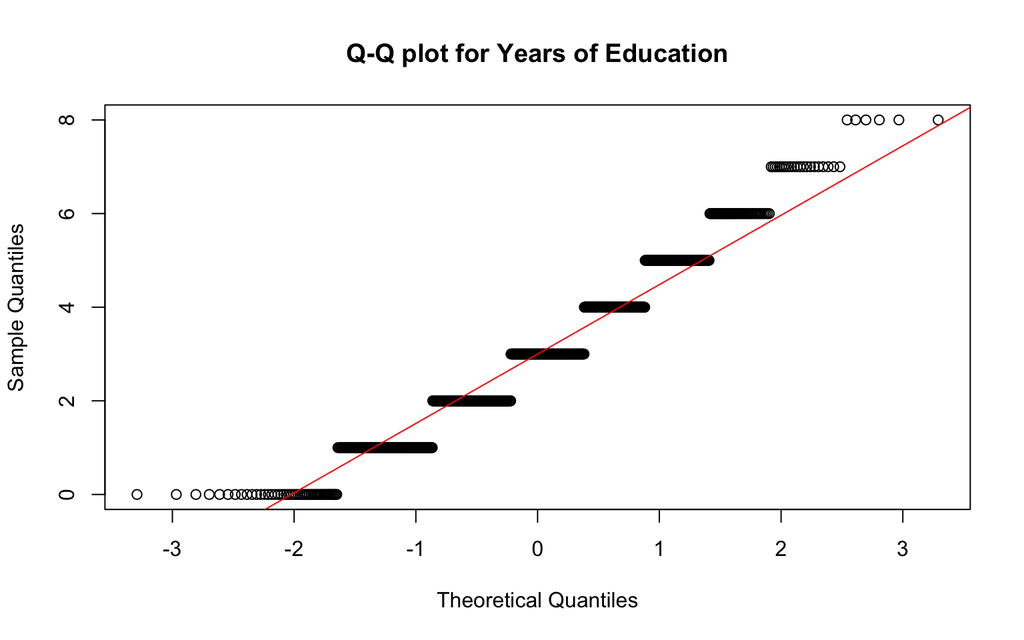

```r
qqnorm(d$years_of_education, main = "Q-Q plot for Years of Education")
qqline(d$years_of_education, col = "red")
```

Height, Weight, and Age appears to be drawn from a normal distribution as they seem to adhere towards the line in the qqplots. In addition, their histograms appear similar to the normal distribution. Years of Education and Zombies Killed did not seem to be drawn from a normal distribution as their qq plots were really different and their histograms appear more similar to poission distributions.

- these look great and I did it essentially the same way, I didn’t add breaks however. I’m not sure if they’re necessary since all of my graphs look similar to yours? - Sofia